# Results - Wells within 1 km of wildfires by state and year (secondary analysis)

# 1 Description

These analyses are for the assessments of the number of wells in all wildfire burn areas by state and year (1984-2020). These are oil and gas wells with any operation date before the year of the wildfire and wells with missing operation dates, which we presume to have been drilled before the study period in an era of poor record-keeping. In a sensitivity analysis, we omit wells without data on operation dates.

# 2 Aggregated results for all states

## 2.1 wells in or near wildfire burn areas

### 2.1.1 Summary of wells in or near wildfire burn areas by year

```
   Min. 1st Qu.  Median    Mean 3rd Qu.    Max.
    830    2190    3602    7814    9770   46954
[1] 9660.468
```

### 2.1.2 Total wells burned by decade

- 1984-1989: **1.284^{4}**
- 1990-1999: **3.4946^{4}**
- 2000-2009: **9.7589^{4}**
- 2010-2019: **1.35933^{5}**

### 2.1.4 Table. wells in or near wildfire burn areas by year

| year | n | n_wells_buffer_1km |
| --- | --- | --- |
| 1984 | 2697 | 2697 |
| 1985 | 1110 | 1110 |
| 1986 | 1650 | 1650 |
| 1987 | 830 | 830 |
| 1988 | 5089 | 5089 |
| 1989 | 1464 | 1464 |
| 1990 | 1364 | 1364 |
| 1991 | 1255 | 1255 |
| 1992 | 1084 | 1084 |
| 1993 | 4495 | 4495 |

[output cut: 26 more lines]

### 2.1.5 Plot. wells in or near wildfire burn areas by year

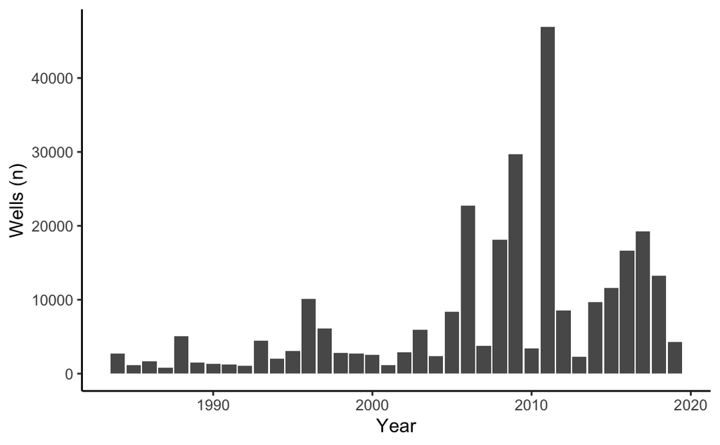

### 2.1.6 Plot. wells in or near wildfire burn areas by year with best fit line

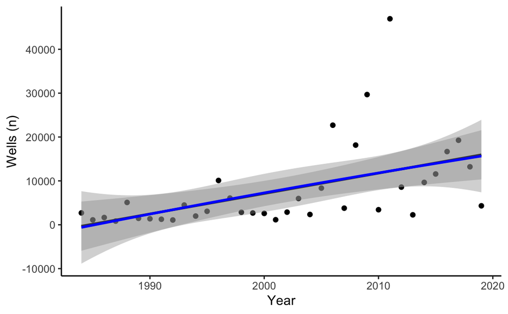

### 2.1.7 Model. Wells in burn area ~ year

```
Call:
glm(formula = n_wells_buffer_1km ~ year, data = wells_wildfire_state_year)

Deviance Residuals:
    Min       1Q   Median       3Q      Max
 -839.2   -542.0   -276.8    -56.7  25758.4

Coefficients:
              Estimate Std. Error t value Pr(>|t|)
(Intercept) -48534.523  12561.812  -3.864 0.000122 ***
year            24.455      6.276   3.896 0.000107 ***
---
Signif. codes:  0 ‘***’ 0.001 ‘**’ 0.01 ‘*’ 0.05 ‘.’ 0.1 ‘ ’ 1

(Dispersion parameter for gaussian family taken to be 2907544)

    Null deviance: 2027088285  on 683  degrees of freedom
Residual deviance: 1982945049  on 682  degrees of freedom
AIC: 12125

Number of Fisher Scoring iterations: 2
```

### 2.1.8 Model. Wells in burn area ~ year * state

```
Call:
glm(formula = n_wells_buffer_1km ~ year + factor(state), data = wells_wildfire_state_year)

Deviance Residuals:
    Min       1Q   Median       3Q      Max
-2668.1   -305.1    -38.9    190.8  24017.0

Coefficients:
                  Estimate Std. Error t value Pr(>|t|)
(Intercept)     -4.895e+04  1.133e+04  -4.319 1.80e-05 ***
year             2.445e+01  5.660e+00   4.321 1.79e-05 ***
factor(state)AR  2.642e+01  3.625e+02   0.073    0.942
factor(state)AZ -3.056e-01  3.625e+02  -0.001    0.999
factor(state)CA  1.892e+03  3.625e+02   5.221 2.39e-07 ***
factor(state)CO  4.339e+01  3.625e+02   0.120    0.905
factor(state)KS  3.331e+02  3.625e+02   0.919    0.358
factor(state)LA  9.808e+01  3.625e+02   0.271    0.787
factor(state)MO -3.056e-01  3.625e+02  -0.001    0.999
factor(state)MT  2.569e+01  3.625e+02   0.071    0.944
factor(state)ND  4.303e+01  3.625e+02   0.119    0.906
factor(state)NE  7.500e-01  3.625e+02   0.002    0.998
factor(state)NM  4.210e+02  3.625e+02   1.162    0.246
factor(state)NV -1.944e-01  3.625e+02  -0.001    1.000
factor(state)OK  2.466e+03  3.625e+02   6.803 2.28e-11 ***
factor(state)OR -3.056e-01  3.625e+02  -0.001    0.999
factor(state)SD  7.722e+00  3.625e+02   0.021    0.983
factor(state)TX  2.152e+03  3.625e+02   5.939 4.64e-09 ***
factor(state)UT  2.039e+01  3.625e+02   0.056    0.955
factor(state)WY  2.792e+02  3.625e+02   0.770    0.441
---
Signif. codes:  0 ‘***’ 0.001 ‘**’ 0.01 ‘*’ 0.05 ‘.’ 0.1 ‘ ’ 1

(Dispersion parameter for gaussian family taken to be 2364671)

    Null deviance: 2027088285  on 683  degrees of freedom
Residual deviance: 1570141790  on 664  degrees of freedom
AIC: 12001

Number of Fisher Scoring iterations: 2
```

## 2.2 Wells within 1 km of wildfire burn areas

### 2.2.1 Plot. Wells within 1km of wildfire burn areas by year

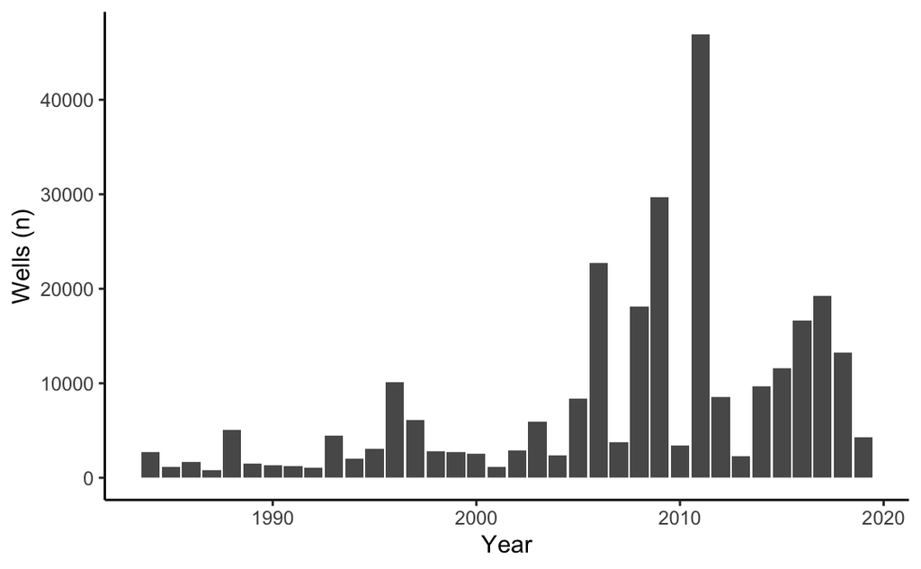

### 2.2.2 Plot. Wells within 1 km of wildfire burn areas by year with best fit line

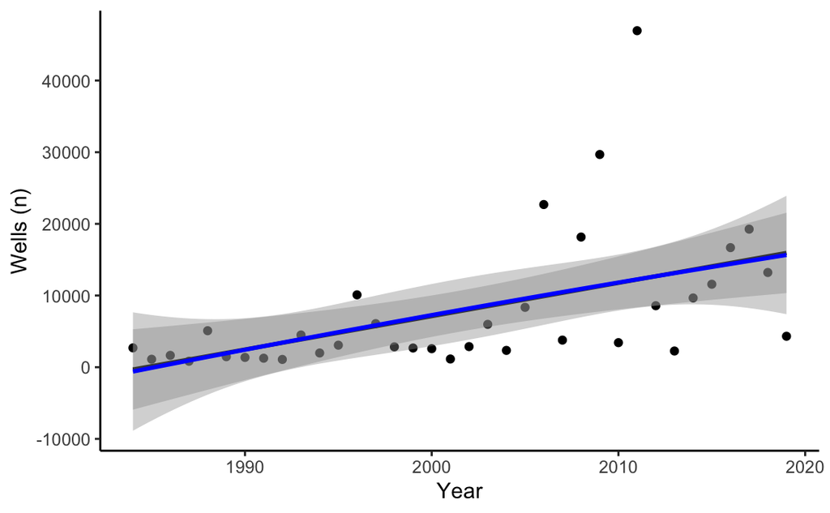

### 2.2.3 Model. Wells within 1km of burn area ~ year * state

```
Call:
glm(formula = n_wells_buffer_1km ~ year + factor(state), data = wells_wildfire_state_year)

Deviance Residuals:
    Min       1Q   Median       3Q      Max
-2668.1   -305.1    -38.9    190.8  24017.0

Coefficients:
                  Estimate Std. Error t value Pr(>|t|)
(Intercept)     -4.895e+04  1.133e+04  -4.319 1.80e-05 ***
year             2.445e+01  5.660e+00   4.321 1.79e-05 ***
factor(state)AR  2.642e+01  3.625e+02   0.073    0.942
factor(state)AZ -3.056e-01  3.625e+02  -0.001    0.999
factor(state)CA  1.892e+03  3.625e+02   5.221 2.39e-07 ***
factor(state)CO  4.339e+01  3.625e+02   0.120    0.905
factor(state)KS  3.331e+02  3.625e+02   0.919    0.358
factor(state)LA  9.808e+01  3.625e+02   0.271    0.787
factor(state)MO -3.056e-01  3.625e+02  -0.001    0.999
factor(state)MT  2.569e+01  3.625e+02   0.071    0.944
factor(state)ND  4.303e+01  3.625e+02   0.119    0.906
factor(state)NE  7.500e-01  3.625e+02   0.002    0.998
factor(state)NM  4.210e+02  3.625e+02   1.162    0.246
factor(state)NV -1.944e-01  3.625e+02  -0.001    1.000
factor(state)OK  2.466e+03  3.625e+02   6.803 2.28e-11 ***
factor(state)OR -3.056e-01  3.625e+02  -0.001    0.999
factor(state)SD  7.722e+00  3.625e+02   0.021    0.983
factor(state)TX  2.152e+03  3.625e+02   5.939 4.64e-09 ***
factor(state)UT  2.039e+01  3.625e+02   0.056    0.955
factor(state)WY  2.792e+02  3.625e+02   0.770    0.441
---
Signif. codes:  0 ‘***’ 0.001 ‘**’ 0.01 ‘*’ 0.05 ‘.’ 0.1 ‘ ’ 1

(Dispersion parameter for gaussian family taken to be 2364671)

    Null deviance: 2027088285  on 683  degrees of freedom
Residual deviance: 1570141790  on 664  degrees of freedom
AIC: 12001

Number of Fisher Scoring iterations: 2
```

In models adjusted for state, the number of wells within 1km of wildfire burn areas (including wells within and just outside of the burn areas) increased throughout the study period, 1984-2020 (p < 0.001).

# 3 Stratified by state

## 3.1 wells in or near wildfire burn areas

### 3.1.1 Table. wells in or near wildfire burn areas by state

| state | n_wells_buffer_1km_by_state |
| --- | --- |
| OK | 88783 |
| TX | 77498 |
| CA | 68134 |
| NM | 15168 |
| KS | 12001 |
| WY | 10064 |
| LA | 3542 |
| CO | 1573 |
| ND | 1560 |
| AR | 962 |

[output cut: 9 more lines]

### 3.1.2 Plot. wells in or near wildfire burn areas by state

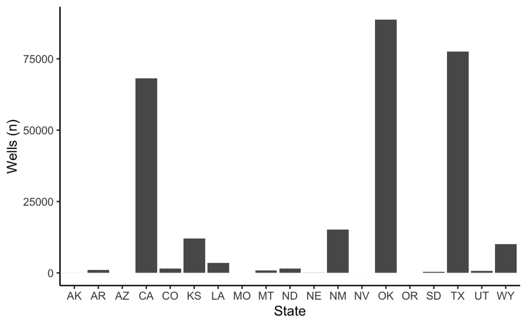

### 3.1.3 Table. wells in or near wildfire burn areas by state and year

| state | year | n | n_wells_buffer_1km |
| --- | --- | --- | --- |
| AK | 1984 | 0 | 0 |
| AK | 1985 | 0 | 0 |
| AK | 1986 | 0 | 0 |
| AK | 1987 | 0 | 0 |
| AK | 1988 | 0 | 0 |
| AK | 1989 | 1 | 1 |
| AK | 1990 | 0 | 0 |
| AK | 1991 | 0 | 0 |
| AK | 1992 | 0 | 0 |
| AK | 1993 | 0 | 0 |

[output cut: 674 more lines]

### 3.1.4 Plot. wells in or near wildfire burn areas by state and year

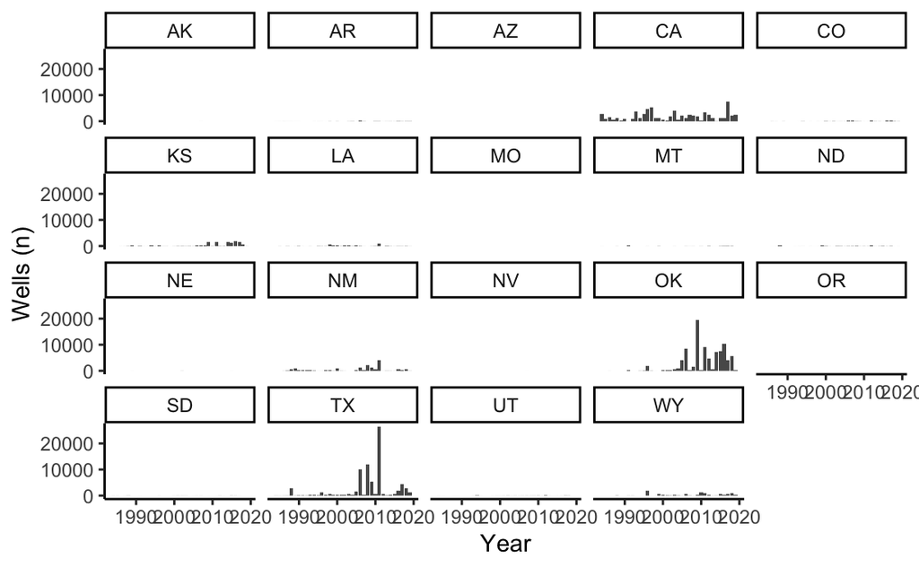

### 3.1.5 Plot. wells in or near wildfire burn areas by year with best fit line

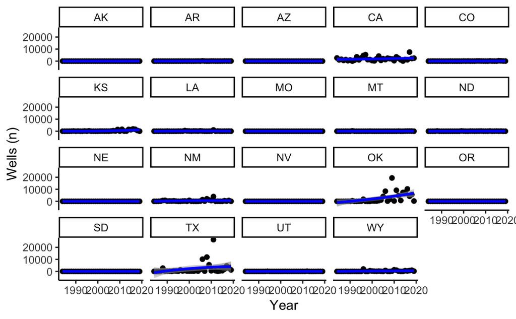

## 3.2 Investigating time trends by state

Fit OLS linear regression models to look at the association between n wells in burn areas and time (in years). Some notable heterogeneity among the three states with the most wells in burn areas.

### 3.2.1 Model. Wells in burn area ~ year * state (CA)

```
Call:
glm(formula = n_wells_buffer_1km ~ year, data = subset(wells_wildfire_state_year,
    state == "CA"))

Deviance Residuals:
    Min       1Q   Median       3Q      Max
-2209.3   -996.3   -327.9    224.9   5159.5

Coefficients:
             Estimate Std. Error t value Pr(>|t|)
(Intercept) -58263.67   51517.78  -1.131    0.266
year            30.06      25.74   1.168    0.251

(Dispersion parameter for gaussian family taken to be 2573845)

    Null deviance: 91020219  on 35  degrees of freedom
Residual deviance: 87510747  on 34  degrees of freedom
AIC: 637.5

Number of Fisher Scoring iterations: 2
```

No time trend in California.

### 3.2.2 Model. Wells in burn area ~ year * state (OK)

```
Call:
glm(formula = n_wells_buffer_1km ~ year, data = subset(wells_wildfire_state_year,
    state == "OK"))

Deviance Residuals:
    Min       1Q   Median       3Q      Max
-6066.9  -1924.6   -423.5    850.9  15323.8

Coefficients:
              Estimate Std. Error t value Pr(>|t|)
(Intercept) -435204.15  115732.79  -3.760 0.000640 ***
year            218.67      57.82   3.782 0.000602 ***
---
Signif. codes:  0 ‘***’ 0.001 ‘**’ 0.01 ‘*’ 0.05 ‘.’ 0.1 ‘ ’ 1

(Dispersion parameter for gaussian family taken to be 12989158)

    Null deviance: 627400746  on 35  degrees of freedom
Residual deviance: 441631386  on 34  degrees of freedom
AIC: 695.77

Number of Fisher Scoring iterations: 2
```

Increasing number of wells in burn areas in Oklahoma (p < 0.01).

### 3.2.3 Model. Wells in burn area ~ year * state (TX)

```
Call:
glm(formula = n_wells_buffer_1km ~ year, data = subset(wells_wildfire_state_year,
    state == "TX"))

Deviance Residuals:
    Min       1Q   Median       3Q      Max
-3653.2  -2080.1   -919.2    -17.8  22899.1

Coefficients:
              Estimate Std. Error t value Pr(>|t|)
(Intercept) -282316.84  153473.90  -1.840   0.0746 .
year            142.13      76.68   1.854   0.0725 .
---
Signif. codes:  0 ‘***’ 0.001 ‘**’ 0.01 ‘*’ 0.05 ‘.’ 0.1 ‘ ’ 1

(Dispersion parameter for gaussian family taken to be 22842160)

    Null deviance: 855112085  on 35  degrees of freedom
Residual deviance: 776633449  on 34  degrees of freedom
AIC: 716.09

Number of Fisher Scoring iterations: 2
```

### 3.2.4 Model. Wells in burn area ~ year * state (KS)

```
Call:
glm(formula = n_wells_buffer_1km ~ year, data = subset(wells_wildfire_state_year,
    state == "KS"))

Deviance Residuals:
   Min      1Q  Median      3Q     Max
-868.7  -290.6   -78.1   168.1  1108.8

Coefficients:
              Estimate Std. Error t value Pr(>|t|)
(Intercept) -62724.708  15060.044  -4.165 0.000201 ***
year            31.505      7.524   4.187 0.000189 ***
---
Signif. codes:  0 ‘***’ 0.001 ‘**’ 0.01 ‘*’ 0.05 ‘.’ 0.1 ‘ ’ 1

(Dispersion parameter for gaussian family taken to be 219948.3)

    Null deviance: 11334456  on 35  degrees of freedom
Residual deviance:  7478242  on 34  degrees of freedom
AIC: 548.95

Number of Fisher Scoring iterations: 2
```

Positive time trend in KS (p = 0.001)

### 3.2.5 Model. Wells in burn area ~ year * state (NM)

```
Call:
glm(formula = n_wells_buffer_1km ~ year, data = subset(wells_wildfire_state_year,
    state == "NM"))

Deviance Residuals:
   Min      1Q  Median      3Q     Max
-657.2  -377.2  -162.8    38.4  3398.1

Coefficients:
             Estimate Std. Error t value Pr(>|t|)
(Intercept) -30668.12   24244.33  -1.265    0.214
year            15.53      12.11   1.282    0.208

(Dispersion parameter for gaussian family taken to be 570018)

    Null deviance: 20317970  on 35  degrees of freedom
Residual deviance: 19380611  on 34  degrees of freedom
AIC: 583.23

Number of Fisher Scoring iterations: 2
```

No time trend in NM

### 3.2.6 Model. Wells in burn area ~ year * state (WY)

```
Call:
glm(formula = n_wells_buffer_1km ~ year, data = subset(wells_wildfire_state_year,
    state == "WY"))

Deviance Residuals:
    Min       1Q   Median       3Q      Max
-435.59  -212.13  -104.91     0.84  1828.11

Coefficients:
              Estimate Std. Error t value Pr(>|t|)
(Intercept) -30532.726  13927.734  -2.192   0.0353 *
year            15.395      6.959   2.212   0.0338 *
---
Signif. codes:  0 ‘***’ 0.001 ‘**’ 0.01 ‘*’ 0.05 ‘.’ 0.1 ‘ ’ 1

(Dispersion parameter for gaussian family taken to be 188117.4)

    Null deviance: 7316713  on 35  degrees of freedom
Residual deviance: 6395993  on 34  degrees of freedom
AIC: 543.32

Number of Fisher Scoring iterations: 2
```